# R4BIGDATA PROJECT:ANALYSIS AND VISUALIZATION OF AIRBNB PARIS DATA

Ashiat Adeogun

10 February 2021

> Note:The associated shiny App has been tested with R version 4.0.3. Image rendering problem may occur on the App with lower versions

## Creation of Shiny application using AirBnB Paris data

Below is the scope of the application:

1. Relationship between apartment price and apartment features
2. Number of apartments per owner
3. Renting price per city quarter
4. Visit frequency of the different quarters according to time

In order to be able to create the shiny application,the data need to be analyzed.

# Below are the steps required to carry out the task:

1. Loading of available data in to ‘R’ environment
2. Joining of the 2 data sets provided.
3. Cleaning the dataset
4. Extracting the relevant data based on the required variables and # of obs
5. Plotting the appropriate charts with relevant variables and providing comments
6. Producing the app files, which requires coding for both server and ui

## Load Required libraries

```r
library(tidyr) #contains tools for changing the shape of a dataset
library(stats) #tools for summarising data into statistics
library(dplyr) #for data manipulation.
```

```r
library(ggplot2)  # for creating graphs
library(scales)   # to access breaks/formatting functions
library(gridExtra) # for arranging plots
library(readr) # to read R data
library(stringr) #provide a cohesive set of functions designed to make working with strings as easy as possible
library(DT)#Helper functions for using DT in Shiny
```

## Loading the raw data

```r
rm(list=ls())
load("C:/Users/ashia/OneDrive - Data ScienceTech Institute/R4BData/airBnB/AirBnB.Rdata")
```

## Joining the two tables contained in the data

There are 2 different data sets which are ‘L’ and ‘R’. The 2 data sets have a common variable. The variable is labelled as ‘id’ in ‘L’ and ‘listing_id’ in ‘R’

```r
df_AirBnB= left_join(L,R,by=c('id'='listing_id'))
```

# =============Data cleaning======

### Using the Zipcode to extract Paris dataset

Since the focus is on Paris data, the data has to be filtered for Paris City. This requires the use of ‘filter’ function and the filtered data set will be assigned to AirBnB_Paris

```r
AirBnB_Paris = filter(df_AirBnB, zipcode == 75001 | zipcode == 75002 | zipcode ==  75003 | zipcode ==  75004 | zipcode ==  75006 | zipcode ==  75007 | zipcode ==  75008 | zipcode ==  75009 | zipcode ==  75010 | zipcode ==  75011 | zipcode ==  75012 | zipcode ==  75013 | zipcode ==  75014 | zipcode ==  75015 | zipcode ==  75016 | zipcode ==  75116 | zipcode ==  75017 | zipcode ==  75018 | zipcode ==  75019 | zipcode ==  75020)
```

### Extracting required columns

```r
AirBnB <- select(AirBnB_Paris,Apartment_id=id,Apartmentname=name,host_id,host_name,
    property_type,city,price,room_type,bed_type,reviews_per_month,cancellation_policy,date,review_scores_communication,review_scores_cleanliness)
```

### Data type conversion for price and date

```r
AirBnB$price <- as.numeric(gsub("[\\$,]","",AirBnB$price))#convert price to numeric
AirBnB$date <-as.Date(AirBnB$date)#convert date to date type
```

### Removing special character from host_name column

```r
AirBnB$host_name <- gsub("[[:punct:]]", "", AirBnB$host_name)#Removing punctuation mark
AirBnB$host_name <- str_replace_all(AirBnB$host_name, "[^[:alnum:]]", "")#Delete non-alphanumeric
```

### Missing data removal and replacement

-`Replace the NAs review_scores_communication and review_scores_cleanliness with median value` -`Remove NAs from date column`

```r
# Exclude the NA from date
AirBnB <- AirBnB[complete.cases(AirBnB$date),]
# Return the column names containing missing Values
list_na <- colnames(AirBnB)[ apply(AirBnB, 2, anyNA) ]
#Replace the median value for review_score_communication and review_scores_cleanliness
replace_median <- apply(AirBnB[,colnames(AirBnB)%in% list_na],2,median,na.rm=TRUE)
AirBnB$review_scores_communication <-AirBnB$review_scores_communication %>% replace_na(10)
AirBnB$review_scores_cleanliness <-AirBnB$review_scores_cleanliness %>% replace_na(9)
```

### Creating new columns for Year and Month Abbreviations

```r
AirBnB <- AirBnB %>%mutate(Year = as.numeric(format(AirBnB$date,"%Y")),
                           Month = as.numeric(format(AirBnB$date,"%m")))
mymonths <-c("Jan","Feb","Mar",
              "Apr","May","Jun",
              "Jul","Aug","Sep",
              "Oct","Nov","Dec")

#add abbreviated month name
AirBnB$MonthAbb <- mymonths[ AirBnB$Month ]
```

# ==============Analysis and Visualisation=========

## Question 1:Relationship between prices and apartment

#### Statistical Analysis to show the relationship between the prices and room_type

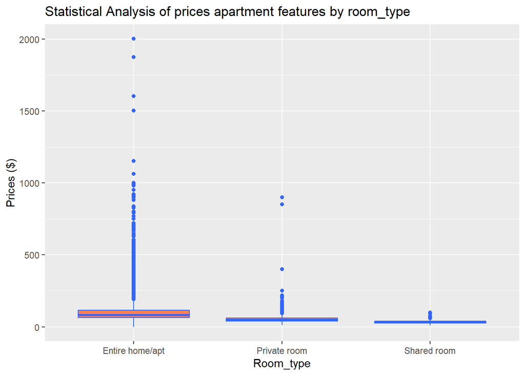

```r
Price_apartment <- AirBnB %>%select(price,room_type,property_type,Apartmentname)%>%filter(property_type=='Apartment') %>%group_by(room_type)
        ggplot(Price_apartment)+geom_boxplot(aes(x=room_type,y= price),fill = "coral",colour = "#3366FF")+
       # scale_size_area() +
        labs(
        x="Room_type" ,
        y="Prices ($)" ,
        title="Statistical Analysis of prices apartment features by room_type")
```

The boxplot here shows that there are few (biased) price values in the dataset which have significant effect on the statistics. It is therefore necessary to remove these entries in order to obtain more accurate statistics. Based on the plots above, a threshold of 200 dollars is set and values above this are treated as outliers.

### Remove of Outlier from the dataset

```r
outlier <- AirBnB%>%select(price,room_type)%>%filter(room_type=="Entire home/apt",price>200)

allentirehome <- AirBnB%>%select(price,room_type)%>%filter(room_type=="Entire home/apt")

outlier_ratio = dim(outlier)[1]/dim(allentirehome)[1]*100

outlier_ratio
```

```
## [1] 5.231852
```

### Box plot after outlier removal from the dataset

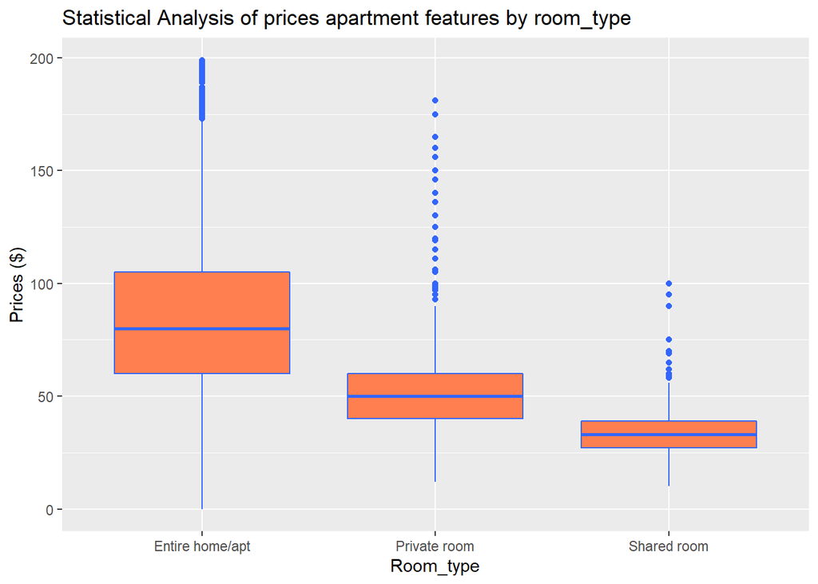

```r
Price_apartment <- AirBnB %>%select(price,room_type,property_type,Apartmentname)%>%filter(property_type=='Apartment',price <200) %>%group_by(room_type)
        ggplot(Price_apartment)+geom_boxplot(aes(x=room_type,y= price),fill = "coral",colour = "#3366FF")+
       # scale_size_area() +
        labs(
        x="Room_type" ,
        y="Prices ($)" ,
        title="Statistical Analysis of prices apartment features by room_type")
```

From the boxplot, we can see that entire apartments and shared rooms have the highest and lowest median prices, respectively. Compare to the other two types, entire homes have significantly larger variation.

### Statistics (Mean,Meadian and standard deviation) for price based on room type

```r
summaryprice <- Price_apartment %>%summarise(
                                  mean=mean(price,na.rm=TRUE),
                                  median=median(price,na.rm=TRUE),
                                  sd =sd(price,na.rm=TRUE))
summaryprice
```

```
## # A tibble: 3 x 4
##   room_type        mean median    sd
## * <fct>           <dbl>  <dbl> <dbl>
## 1 Entire home/apt  87.6     80  34.7
## 2 Private room     51.6     50  17.3
## 3 Shared room      34.8     33  11.6
```

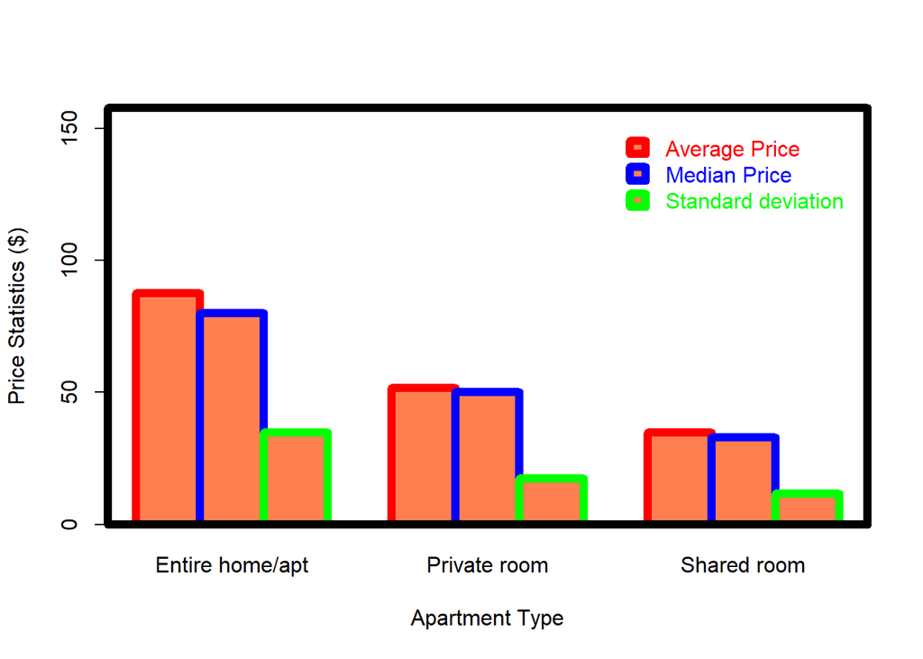

```r
 plot.new()
  cols <- c('red','blue','green');
  ylim <- c(0,max(summaryprice[c('mean','median','sd')])*1.8);
  par(lwd=6);
  barplot(
    t(summaryprice[c('mean','median','sd')]),
    beside=T,
    ylim=ylim,
    border=cols,
    col='coral',
    names.arg=summaryprice$room_type,
    xlab='Apartment Type',
    ylab='Price Statistics ($)',
    legend.text=c('Average Price','Median Price','Standard deviation'),
    args.legend=list(text.col=cols,col=cols,border=cols,bty='n'),

  )
  box();
```

### Analysis of relationship between prices and bed_type

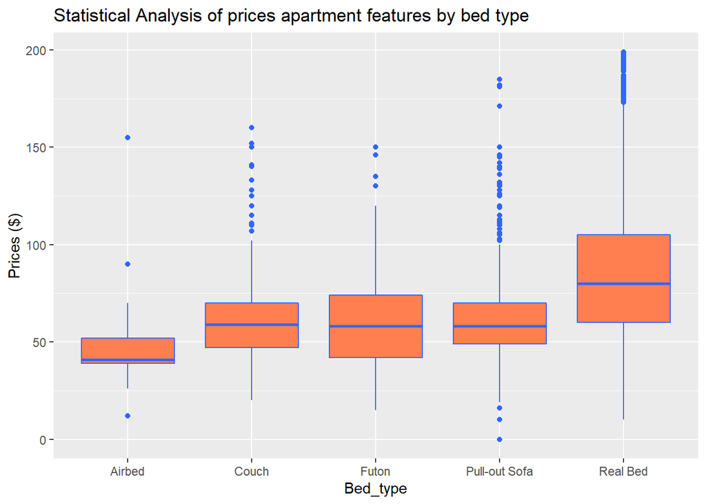

```r
Price_apartmentbed_type <- AirBnB%>%select(price,property_type,bed_type)%>%
  filter(property_type=='Apartment',price<200) %>%group_by(bed_type)
        ggplot(Price_apartmentbed_type)+geom_boxplot(aes(x=bed_type,y= price),fill = "coral",colour = "#3366FF")+
       # scale_size_area() +
        labs(
        x="Bed_type" ,
        y="Prices ($)" ,
        title="Statistical Analysis of prices apartment features by bed type")
```

The box plot shows that apartments with real bead has the slightly median rent than those with futon, pull-out sofa, couch and air bed. The lowest median value is seen for apartments with airbed.

## Question2:Number of apartments per owner

```r
NumberOfApartmentsPerOwner <- AirBnB %>% select(Apartment_id,host_id,host_name,property_type)%>%
  filter(property_type == "Apartment") %>%
  group_by(host_name) %>%
  summarise(Total=n_distinct(Apartment_id))%>%arrange(desc(Total))
datatable(NumberOfApartmentsPerOwner,colnames = c('Name_of_owner'=2,'Number_of_Apartment'=3))
```

|  | Name_of_owner | Number_of_Apartment |
| --- | --- | --- |
| 1 | Marie | 384 |
| 2 | Nicolas | 312 |
| 3 | Caroline | 278 |
| 4 | Pierre | 276 |
| 5 | Camille | 257 |
| 6 | Julien | 257 |
| 7 | Sophie | 251 |
| 8 | Anne | 249 |
| 9 | Olivier | 233 |
| 10 | Thomas | 222 |

[output cut: 6903 more lines]

The table allows visualization of the number of apartments owned by each owner as contained in the data set.

### Scatter plot for number of apartment per owner

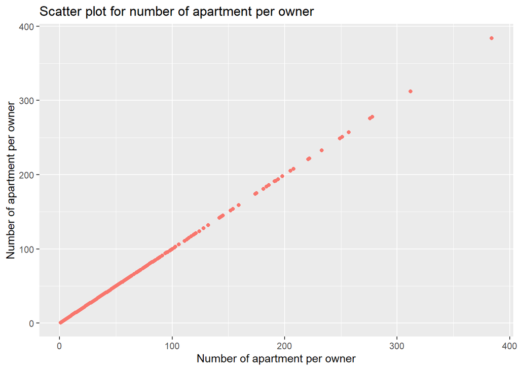

```r
ggplot(NumberOfApartmentsPerOwner,aes(Total,Total))+geom_point(aes(colour ="red"))+
  theme(legend.position = "none")+
  labs(
    x ="Number of apartment per owner",
    y ="Number of apartment per owner",
    title = "Scatter plot for number of apartment per owner"
  )
```

### Grouping the number of apartment per owners

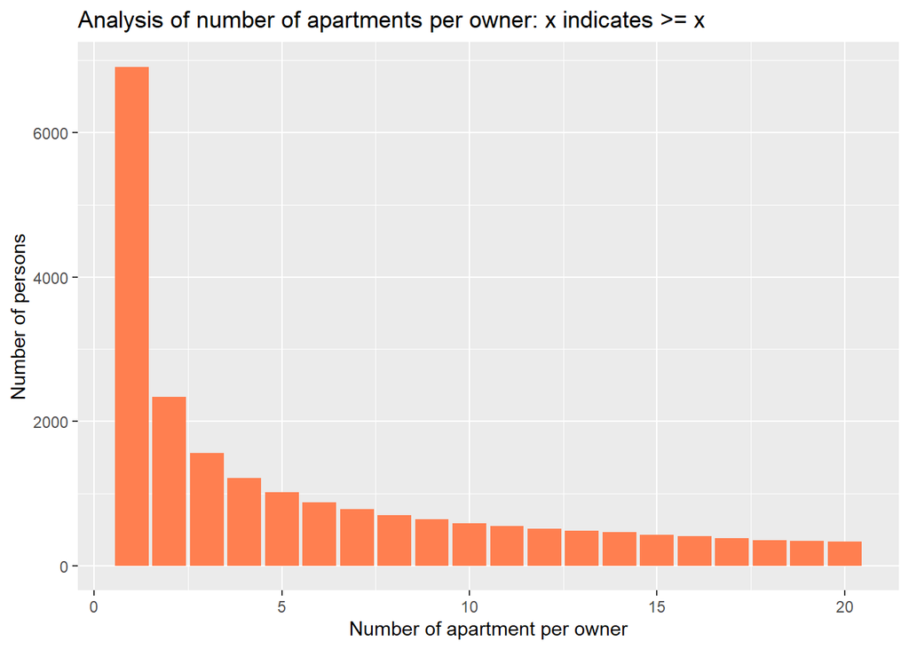

```r
Name <-list(unique(AirBnB$host_name))

NumberOfApartmentsPerOwner <- AirBnB %>% select(Apartment_id,host_id,host_name,property_type)%>%
    filter(property_type == "Apartment") %>%
    group_by(host_name) %>%
    summarise(Total=n_distinct(Apartment_id))%>%arrange(desc(Total))
num_list <- rep(0,20)

for (i in 1:20){
  if (i < 1){
    num_list[i] = length(which(NumberOfApartmentsPerOwner$Total == i))
  }
  else{
    num_list[i] = length(which(NumberOfApartmentsPerOwner$Total >= i))
  }
}
df_number_apartment <- data.frame(num_list,Number_per_owner=c(1:20))
   ggplot(df_number_apartment,aes(Number_per_owner,num_list))+ geom_bar(stat = "identity",fill='coral')+

   labs(
    x="Number of apartment per owner" ,
    y="Number of persons" ,
    title="Analysis of number of apartments per owner: x indicates >= x")
```

This bar plot shows that significant number of owners have below 10 apartments with the largest percentage having only one apartment.

## Question3:Renting prices per city quarter (“arrondissements”)

Extracting all Paris Arrondissement Quarters and performing statistical analysis of the data based on prices per apartment.

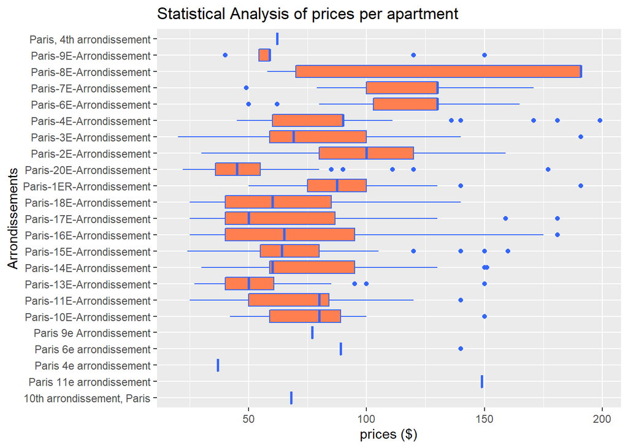

```r
target <-c("Paris-17E-Arrondissement",
            "Paris-7E-Arrondissement",
            "Paris-19E-Arrondissement ",
            "Paris-20E-Arrondissement",
            "Paris-9E-Arrondissement",
            "Paris 9e Arrondissement",
            "Paris-10E-Arrondissement",
            "Paris-11E-Arrondissement",
            "10th arrondissement, Paris",
            "Paris-13E-Arrondissement",
            "Paris-14E-Arrondissement",
            "Paris-15E-Arrondissement",
            " Paris-12E-Arrondissement",
            "Paris-1ER-Arrondissement",
            "Paris-2E-Arrondissement",
            "Paris-6E-Arrondissement",
            "Paris 6e arrondissement",
            "Paris-8E-Arrondissement",
            "Paris-3E-Arrondissement",
            "Paris-16E-Arrondissement",
            "Paris 11e arrondissement",
            "Paris-18E-Arrondissement",
            "Paris-4E-Arrondissement",
            "Paris 4e arrondissement",
            "Paris, 4th arrondissement")
arrondissement <-AirBnB%>%select(city,price)%>%filter(city%in%target,price<200)%>%group_by(city)
ggplot(arrondissement)+
  geom_boxplot(aes(x=price,y= city),
        fill = "coral",colour = "#3366FF")+
        labs(
        x="prices ($)" ,
        y="Arrondissements" ,
        title="Statistical Analysis of prices per apartment")
```

A boxplot of the price per apartment statistics for the different arrondissements. Further analysis are presented below.

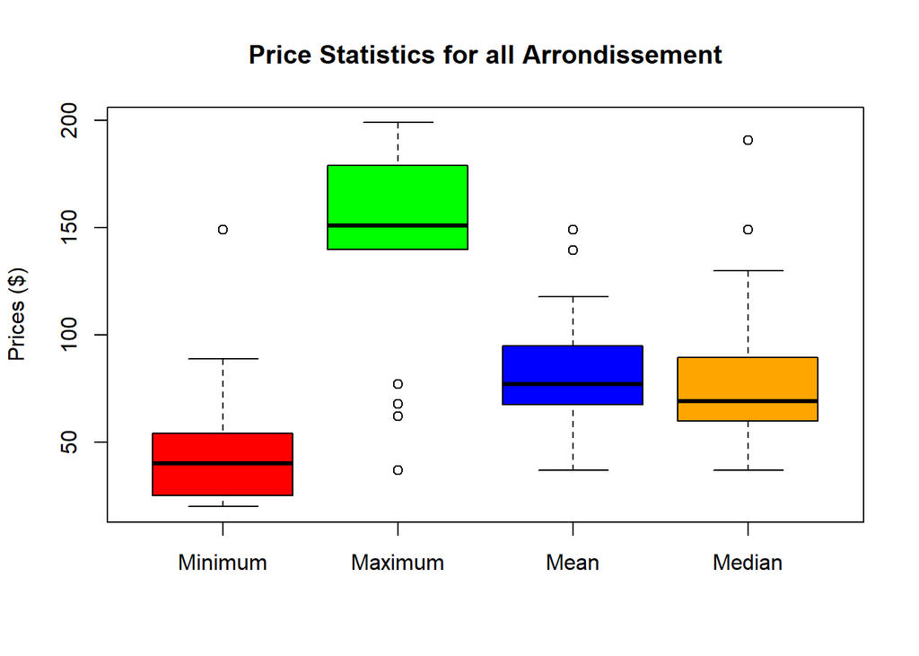

```r
TabArr <- arrondissement %>% group_by(city)%>%
                summarise(mean=mean(price),
                median=median(price),
                max=max(price),
                min=min(price)
                )

A <- matrix(data=0,nrow=23,ncol = 4)

A[,1] = TabArr$min
A[,2] = TabArr$max
A[,3] = TabArr$mean
A[,4] = TabArr$median
boxplot(A, col=c("red","green","blue","orange"),
names = c("Minimum", "Maximum", "Mean", "Median"),
main ="Price Statistics for all Arrondissement",
ylab = "Prices ($)"
)
```

### Average prices per Arrondisement

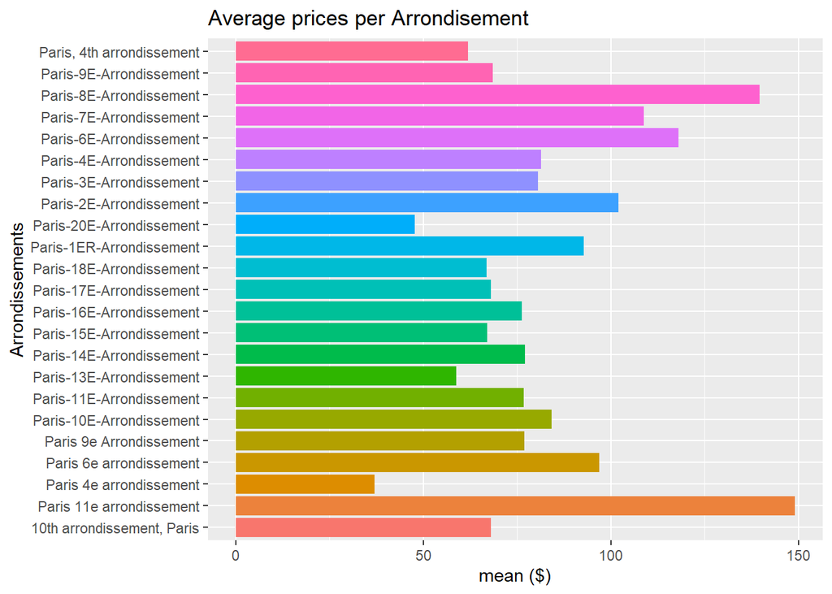

```r
 TabArr1 <- TabArr%>%select(city,mean)%>%filter(mean <= 300)
 ggplot(TabArr1,aes(mean,city,fill=factor(city)))+geom_bar(stat="identity")+
   theme(legend.position = "none")+ labs(
       x="mean ($)",
       y="Arrondissements",
       title ="Average prices per Arrondisement")
```

## Question4:Visit frequency of the different quarrters according to time.

### Frequency visit for per year

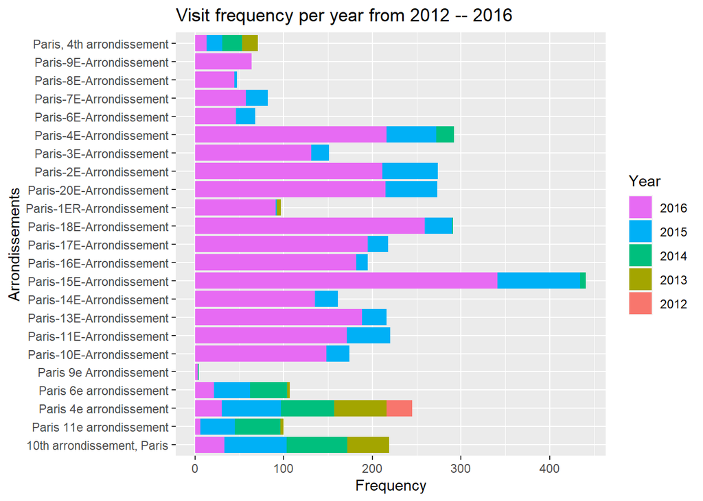

```r
frequency_years_visit <-AirBnB%>%select(city,Year)%>%filter(city%in% target)
         ggplot(data = frequency_years_visit) +
         geom_bar(aes(y = factor(city),fill=factor(Year)))+
            guides(fill = guide_legend(reverse=TRUE))+
         labs(
         x="Frequency" ,
         y="Arrondissements" ,
        fill="Year",
        title="Visit frequency per year from 2012 -- 2016")
```

The frequency of visit to the arrondisements appear to increase each year from 2013 to 2016. For most of the apartments, visits in 2012 and 2013 were limited compared to subsequent years.

### Visit frequency per month

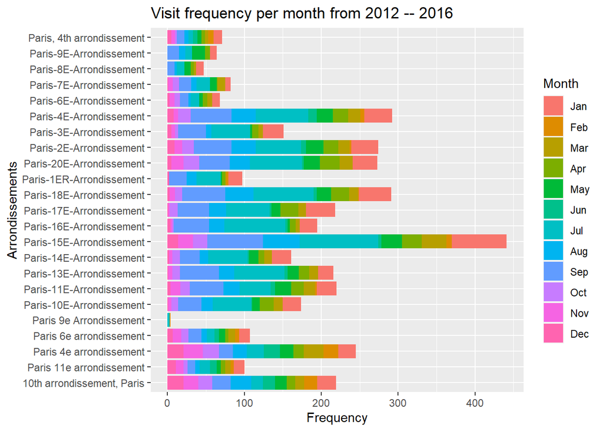

```r
Frequency_month_visit <-AirBnB%>%select(MonthAbb,city)%>%
          filter(city%in% target)%>%arrange(MonthAbb)
ggplot(data = Frequency_month_visit) +
geom_bar(aes(y = factor(city),fill=factor(MonthAbb)))+
  scale_fill_discrete(name = "Month", labels =c("Jan", "Feb", "Mar","Apr","May","Jun","Jul","Aug","Sep","Oct","Nov","Dec"))+
  scale_size_area() +
  labs(
  x="Frequency" ,
  y="Arrondissements" ,
  fill="month",
  title="Visit frequency per month from 2012 -- 2016")
```

### Cancellation_policy by Quarters

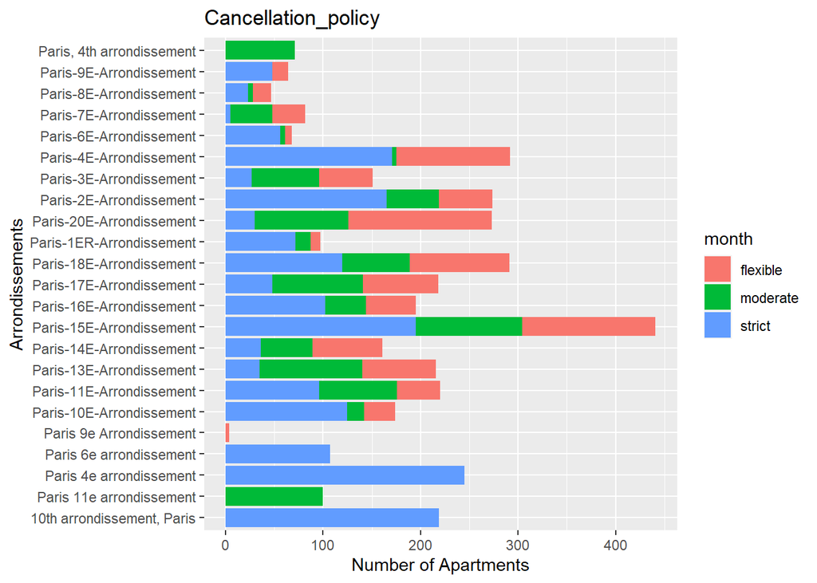

```r
policy <- AirBnB %>% select(city,cancellation_policy)%>% filter(city %in% target)
 ggplot(data=policy)+
  geom_bar(aes(y =factor(city),fill=factor(cancellation_policy)))+
   scale_size_area() +
  labs(
  x="Number of Apartments" ,
  y="Arrondissements" ,
  fill="month",
  title="Cancellation_policy")
```

### review_score_communication

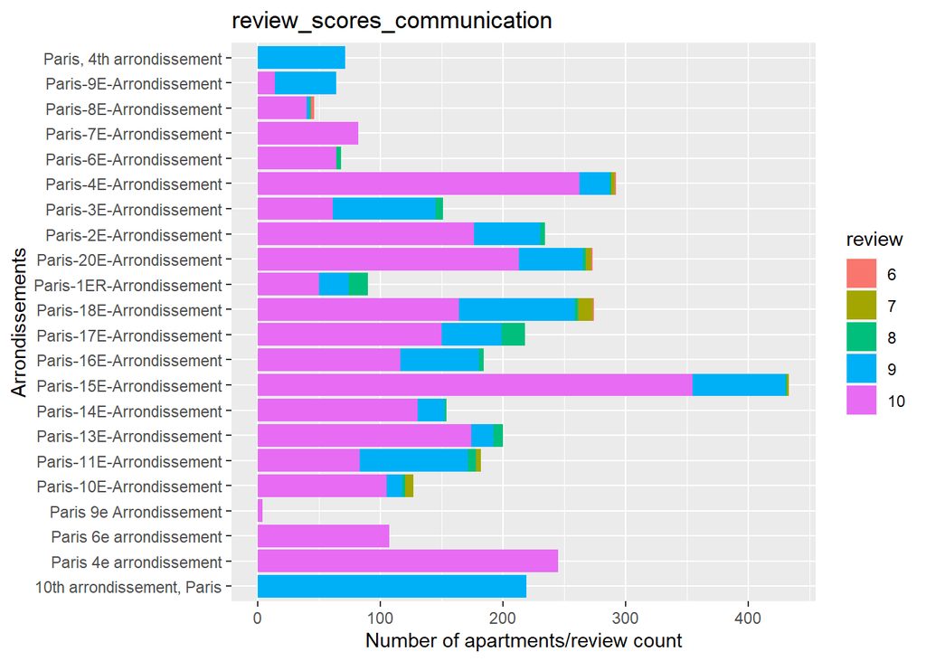

```r
Review_communication<-AirBnB%>%
  select(city,review_scores_communication,property_type)%>%
  filter(city%in%target,property_type=='Apartment')%>%group_by(city)%>%arrange(desc(review_scores_communication))
 ggplot(data=Review_communication)+
  geom_bar(aes(y =factor(city),fill=factor(review_scores_communication)))+
   scale_size_area() +
  labs(
  x="Number of apartments/review count" ,
  y="Arrondissements" ,
  fill="review",
  title="review_scores_communication")
```

## review_score_cleanliness

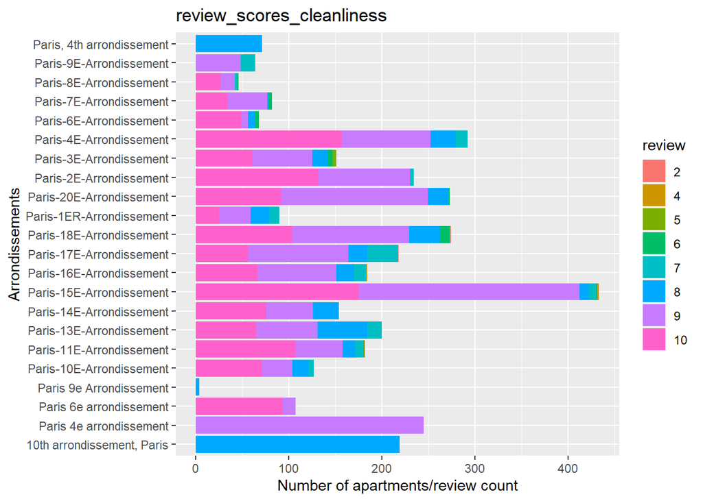

```r
Review_cleanliness<-AirBnB%>%select(city,review_scores_cleanliness,property_type)%>%filter(city%in%target,property_type=='Apartment')%>%group_by(city)%>%arrange(desc(review_scores_cleanliness))
 ggplot(data=Review_cleanliness)+
  geom_bar(aes(y =factor(city),fill=factor(review_scores_cleanliness)))+
   scale_size_area() +
  labs(
  x="Number of apartments/review count" ,
  y="Arrondissements" ,
  fill="review",
  title="review_scores_cleanliness")
```

```r
setwd("C:/Users/ashia/OneDrive - Data ScienceTech Institute/SHINY")
save(AirBnB,file= 'fileAirBnB.Rdata')
save.image()
```